# Untitled

Piyush Singh

7/31/2021

## COLLECTING DATA

```r
library(tidyverse) #helps wrangle data
library(lubridate) #helps wrangle date attributes
```

```r
library(ggplot2) #helps visualize data

library(readr)
```

### Reading all the .csv files for year 2020 :

Divvy_Trips_2020_Q1 <- read_csv(“…/Divvy_Trips_2020_Q1.csv”) View(Divvy_Trips_2020_Q1)

Divvy_tripdata_2020_04 <- read_csv(“…/202004-divvy-tripdata.csv”)

Divvy_tripdata_2020_05 <- read_csv(“…/202005-divvy-tripdata.csv”)

Divvy_tripdata_2020_06 <- read_csv(“…/202006-divvy-tripdata.csv”)

Divvy_tripdata_2020_07<- read_csv(“…/202007-divvy-tripdata.csv”) View(Divvy_tripdata_2020_07)

Divvy_tripdata_2020_08 <- read_csv(“C:/Users/piyus/Desktop/bike-share PROJECT/202008-divvy-tripdata.csv”)

Divvy_tripdata_2020_09<- read_csv(“…/202009-divvy-tripdata.csv”)

Divvy_tripdata_2020_10<- read_csv(“…/202010-divvy-tripdata.csv”) Divvy_tripdata_2020_11<- read_csv(“…/202011-divvy-tripdata.csv”) Divvy_tripdata_2020_12<- read_csv(“…/202012-divvy-tripdata.csv”)

## WRANGLE DATA AND COMBINE INTO A SINGLE FILE

### changing the data type of started_at,ended_at columns to date_time :

```r
Divvy_tripdata_2020_10$started_at <- dmy_hm(Divvy_tripdata_2020_10$started_at)
Divvy_tripdata_2020_10$ended_at <- dmy_hm(Divvy_tripdata_2020_10$ended_at)
View(Divvy_tripdata_2020_10)
```

### Merging the monthly files into respective quarter files :

#### Merging the tables for Q2 :-

Divvy_tripdata_2020_Q2 <- bind_rows(Divvy_tripdata_2020_04 , Divvy_tripdata_2020_05,Divvy_tripdata_2020_06) View(Divvy_Trips_2020_Q2)

#### Merging the tables for Q3:-

Divvy_tripdata_2020_Q3<-bind_rows(Divvy_tripdata_2020_07 , Divvy_tripdata_2020_08,Divvy_tripdata_2020_09) View(Divvy_Trips_2020_Q3)

#### Merging the tables for Q4:- <-

Divvy_tripdata_2020_Q4 <- bind_rows(Divvy_tripdata_2020_10 , Divvy_tripdata_2020_11,Divvy_tripdata_2020_12) View(Divvy_tripdata_2020_Q4)

### Changing the datatype of station id to double……………

Divvy_tripdata_2020_12$start_station_id <- as.double(Divvy_tripdata_2020_12$start_station_id) Divvy_tripdata_2020_12$end_station_id <- as.double(Divvy_tripdata_2020_12$end_station_id)

### Creating the ride_length column :

Divvy_tripdata_2020_Q1$ride_length <- difftime(Divvy_tripdata_2020_Q1$ended_at,Divvy_tripdata_2020_Q1$started_at) Divvy_tripdata_2020_Q2$ride_length <- difftime(Divvy_tripdata_2020_Q2$ended_at,Divvy_tripdata_2020_Q2$started_at) Divvy_tripdata_2020_Q3$ride_length <- difftime(Divvy_tripdata_2020_Q3$ended_at,Divvy_tripdata_2020_Q3$started_at) Divvy_tripdata_2020_Q4$ride_length <- difftime(Divvy_tripdata_2020_Q4$ended_at,Divvy_tripdata_2020_Q4$started_at)

### Dropping the unnecessary columns

Divvy_Trips_2020_Q1<- Divvy_Trips_2020_Q1 %>% select(-c(start_lat, start_lng, end_lat, end_lng))

Divvy_tripdata_2020_04<- Divvy_tripdata_2020_04 %>% select(-c(start_lat, start_lng, end_lat, end_lng))

Divvy_tripdata_2020_05<- Divvy_tripdata_2020_05 %>% select(-c(start_lat, start_lng, end_lat, end_lng))

Divvy_tripdata_2020_06<- Divvy_tripdata_2020_06 %>% select(-c(start_lat, start_lng, end_lat, end_lng))

Divvy_tripdata_2020_07<- Divvy_tripdata_2020_07 %>% select(-c(start_lat, start_lng, end_lat, end_lng))

Divvy_tripdata_2020_08<- Divvy_tripdata_2020_08 %>% select(-c(start_lat, start_lng, end_lat, end_lng))

Divvy_tripdata_2020_09<- Divvy_tripdata_2020_09 %>% select(-c(start_lat, start_lng, end_lat, end_lng))

Divvy_tripdata_2020_10<- Divvy_tripdata_2020_10 %>% select(-c(start_lat, start_lng, end_lat, end_lng))

Divvy_tripdata_2020_11<- Divvy_tripdata_2020_11 %>% select(-c(start_lat, start_lng, end_lat, end_lng))

Divvy_tripdata_2020_12<- Divvy_tripdata_2020_12 %>% select(-c(start_lat, start_lng, end_lat, end_lng))

### Merging the quarter files of 2020 into one year file ……………….

Divvy_2020_data <- bind_rows(Divvy_tripdata_2020_Q1 , Divvy_tripdata_2020_Q2,Divvy_tripdata_2020_Q3,Divvy_tripdata_2020_Q4)

```r
Divvy_2020_data <- read_csv("C:/Users/piyus/Desktop/bike-share PROJECT/Divvy_2020_data.csv")
```

### Creating new columns- date,month,day_of_week,Year :

```r
Divvy_2020_data$date <- format(as.Date(Divvy_2020_data$started_at, "%Y-%m-%d"), "%d-%m-%Y" )#The default format is yyyy-mm-dd
Divvy_2020_data$month <- format(as.Date(Divvy_2020_data$date), "%m")
Divvy_2020_data$day <- format(as.Date(Divvy_2020_data$date), "%d")
Divvy_2020_data$year <- format(as.Date(Divvy_2020_data$date), "%Y")
Divvy_2020_data$day_of_week <- format(as.Date(Divvy_2020_data$date), "%A")
```

## CONDUCT DESCRIPTIVE ANALYSIS

```r
 summary(Divvy_2020_data)
```

```
##    ride_id          rideable_type        started_at
##  Length:3541683     Length:3541683     Min.   :2020-01-01 00:04:00
##  Class :character   Class :character   1st Qu.:2020-06-18 19:10:40
##  Mode  :character   Mode  :character   Median :2020-08-09 11:42:17
##                                        Mean   :2020-07-28 22:19:49
##                                        3rd Qu.:2020-09-25 10:54:24
##                                        Max.   :2020-12-31 23:59:00
##
##     ended_at                    ride_length       start_station_name
##  Min.   :2020-01-01 00:10:00   Min.   :-1743000   Length:3541683
##  1st Qu.:2020-06-18 19:41:00   1st Qu.:     460   Class :character
##  Median :2020-08-09 12:14:22   Median :     840   Mode  :character
##  Mean   :2020-07-28 22:44:39   Mean   :    1490
##  3rd Qu.:2020-09-25 11:18:17   3rd Qu.:    1560
##  Max.   :2021-01-03 08:54:00   Max.   : 9387024
##
##  start_station_id  end_station_name   end_station_id    member_casual
##  Min.   :    2.0   Length:3541683     Min.   :    2.0   Length:3541683
##  1st Qu.:   94.0   Class :character   1st Qu.:   95.0   Class :character
##  Median :  196.0   Mode  :character   Median :  196.0   Mode  :character
##  Mean   :  406.6                      Mean   :  407.4
##  3rd Qu.:  317.0                      3rd Qu.:  317.0
##  Max.   :20254.0                      Max.   :20254.0
##  NA's   :164182                       NA's   :178878
##      date              month               day                year
##  Length:3541683     Length:3541683     Length:3541683     Length:3541683
##  Class :character   Class :character   Class :character   Class :character
##  Mode  :character   Mode  :character   Mode  :character   Mode  :character
##
##
##
##
##  day_of_week
##  Length:3541683
##  Class :character
##  Mode  :character
##
##
##
##
```

```r
aggregate(Divvy_2020_data$ride_length ~ Divvy_2020_data$member_casual, FUN = mean)
```

```
##   Divvy_2020_data$member_casual Divvy_2020_data$ride_length
## 1                        casual                   2739.2522
## 2                        member                    705.2016
```

```r
aggregate(Divvy_2020_data$ride_length ~ Divvy_2020_data$member_casual, FUN = median)
```

```
##   Divvy_2020_data$member_casual Divvy_2020_data$ride_length
## 1                        casual                        1290
## 2                        member                         660
```

```r
aggregate(Divvy_2020_data$ride_length ~ Divvy_2020_data$member_casual, FUN = max)
```

```
##   Divvy_2020_data$member_casual Divvy_2020_data$ride_length
## 1                        casual                     9387024
## 2                        member                     5627611
```

```r
aggregate(Divvy_2020_data$ride_length ~ Divvy_2020_data$member_casual, FUN = min)
```

```
##   Divvy_2020_data$member_casual Divvy_2020_data$ride_length
## 1                        casual                    -1739760
## 2                        member                    -1743000
```

### the average ride time by each day for members vs casual users

```r
aggregate(Divvy_2020_data$ride_length ~ Divvy_2020_data$member_casual + Divvy_2020_data$day_of_week, FUN = mean)
```

```
##    Divvy_2020_data$member_casual Divvy_2020_data$day_of_week
## 1                         casual                      Friday
## 2                         member                      Friday
## 3                         casual                      Monday
## 4                         member                      Monday
## 5                         casual                    Saturday
## 6                         member                    Saturday
## 7                         casual                      Sunday
## 8                         member                      Sunday
## 9                         casual                    Thursday
## 10                        member                    Thursday
## 11                        casual                     Tuesday
## 12                        member                     Tuesday
## 13                        casual                   Wednesday
## 14                        member                   Wednesday
##    Divvy_2020_data$ride_length
## 1                    2931.7786
## 2                     957.3766
## 3                    2773.5929
## 4                     950.5689
## 5                    2674.0375
## 6                     913.1382
## 7                    2211.9739
## 8                    -657.4137
## 9                    2778.4281
## 10                    930.0761
## 11                   2855.2139
## 12                    941.3656
## 13                   2961.7818
## 14                    974.1628
```

### correcting the order of days in week

```r
Divvy_2020_data$day_of_week <- ordered(Divvy_2020_data$day_of_week, levels=c("Sunday" ,"Monday", "Tuesday", "Wednesday", "Thursday", "Friday", "Saturday"))
```

### Analyzing ridership data by type and weekday

```r
Divvy_2020_data %>%
  mutate(weekday = wday(started_at, label = TRUE)) %>%
  group_by(member_casual, weekday) %>%
  summarise(number_of_rides = n() , average_duration = mean(ride_length)) %>%
  arrange(member_casual,weekday) # sorts
```

```
## # A tibble: 14 x 4
## # Groups:   member_casual [2]
##    member_casual weekday number_of_rides average_duration
##    <chr>         <ord>             <int>            <dbl>
##  1 casual        Sun              256148            3247.
##  2 casual        Mon              141652            2780.
##  3 casual        Tue              137572            1571.
##  4 casual        Wed              152524            2550.
##  5 casual        Thu              162689            2776.
##  6 casual        Fri              202187            2713.
##  7 casual        Sat              313803            2908.
##  8 member        Sun              271072            1085.
##  9 member        Mon              292044             894.
## 10 member        Tue              315495            -758.
## 11 member        Wed              329484             885.
## 12 member        Thu              328589             884.
## 13 member        Fri              326048             928.
## 14 member        Sat              312376            1067.
```

### Visualizing the number of rides by rider type

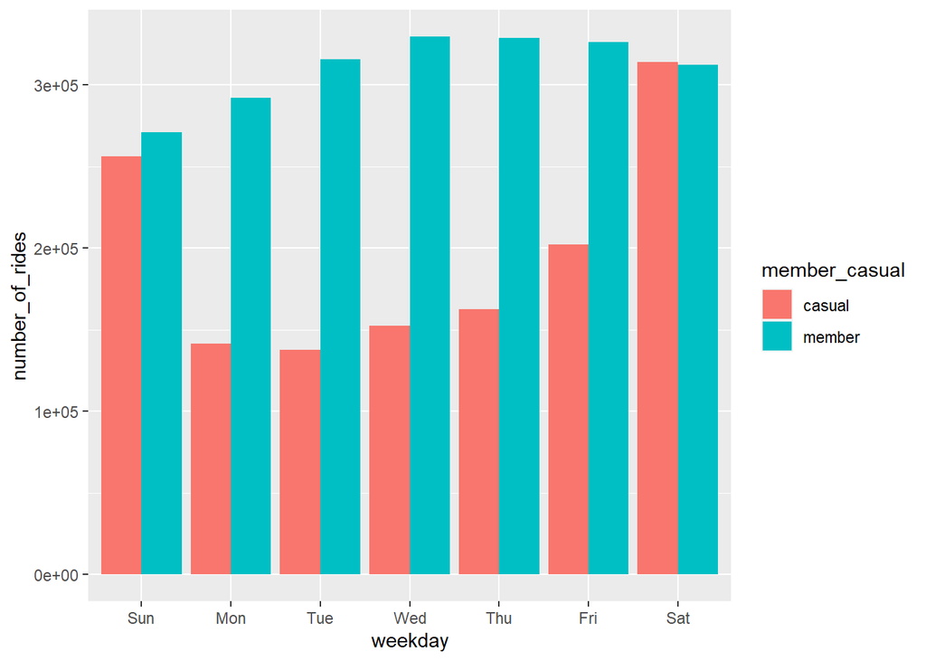

```r
Divvy_2020_data %>%
  mutate(weekday = wday(started_at, label = TRUE)) %>%
  group_by(member_casual, weekday) %>%
  summarise(number_of_rides = n(),average_duration = mean(ride_length)) %>%
  arrange(member_casual, weekday) %>%
  ggplot(mapping=aes(x = weekday, y = number_of_rides, fill = member_casual)) +
  geom_col(position = "dodge")
```

### Creating a visualization for average duration

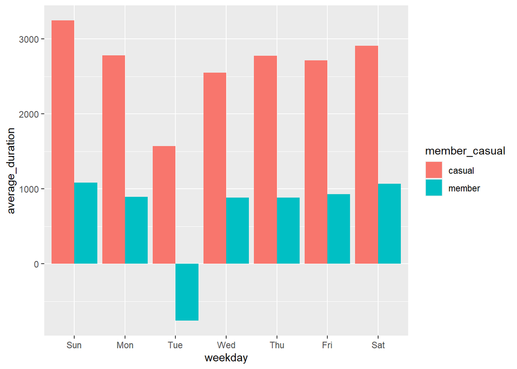

```r
Divvy_2020_data%>%
  mutate(weekday = wday(started_at, label = TRUE)) %>%
  group_by(member_casual, weekday) %>%
  summarise(number_of_rides = n(),average_duration = mean(ride_length)) %>%
  arrange(member_casual, weekday) %>%
  ggplot(aes(x = weekday, y = average_duration, fill = member_casual)) +
  geom_col(position = "dodge")
```

### Comparing general bike type preference between members and casual riders

```r
Divvy_2020_data %>%
  group_by(rideable_type, member_casual) %>%
  summarize(number_of_rides = n(), .groups = 'drop')
```

```
## # A tibble: 6 x 3
##   rideable_type member_casual number_of_rides
##   <chr>         <chr>                   <int>
## 1 classic_bike  casual                  11319
## 2 classic_bike  member                  59297
## 3 docked_bike   casual                1146030
## 4 docked_bike   member                1820292
## 5 electric_bike casual                 209226
## 6 electric_bike member                 295519
```

### Comparing number of docked_bike rides between members and casual riders for each day of week

```r
Divvy_2020_data%>%
  filter(rideable_type == 'docked_bike') %>%
  mutate(weekday=wday(started_at,label=TRUE))%>%
  group_by(member_casual, weekday) %>%
  summarise(number_of_rides = n(), .groups = 'drop') %>%
  arrange(weekday)
```

```
## # A tibble: 14 x 3
##    member_casual weekday number_of_rides
##    <chr>         <ord>             <int>
##  1 casual        Sun              221426
##  2 member        Sun              227015
##  3 casual        Mon              117181
##  4 member        Mon              244262
##  5 casual        Tue              112729
##  6 member        Tue              265896
##  7 casual        Wed              124479
##  8 member        Wed              276344
##  9 casual        Thu              132328
## 10 member        Thu              273550
## 11 casual        Fri              167853
## 12 member        Fri              272290
## 13 casual        Sat              270034
## 14 member        Sat              260935
```

### Docked_bike rides of casual riders for each day of week

```r
Divvy_2020_data %>%
  filter(rideable_type == 'docked_bike', member_casual == 'casual') %>%
  mutate(weekday=wday(started_at,label=TRUE)) %>%
  group_by(weekday) %>%
  summarise(number_of_rides = n(), .groups = 'drop')
```

```
## # A tibble: 7 x 2
##   weekday number_of_rides
##   <ord>             <int>
## 1 Sun              221426
## 2 Mon              117181
## 3 Tue              112729
## 4 Wed              124479
## 5 Thu              132328
## 6 Fri              167853
## 7 Sat              270034
```

### Creating a custom theme

```r
custom_theme = theme(plot.title=element_text(size=20),
                 axis.text.x=element_text(size=9),
                 axis.text.y=element_text(size=16),
                 axis.title.x=element_text(size=18),
                 axis.title.y=element_text(size=18),
                 strip.text.x=element_text(size=16),
                 strip.text.y=element_text(size=16),
                 legend.title=element_text(size=18),
                 legend.text=element_text(size=16))
```

Divvy_2020_data %>% mutate(month_name=month(started_at,label=TRUE))%>% group_by(month_name, member_casual) %>% summarize(number_of_rides = n(), .groups = ‘drop’) %>% filter(member_casual == ‘casual’) %>% drop_na() %>% ggplot(aes(x = month_name, y = number_of_rides, fill = member_casual)) + geom_bar(position = ‘dodge’, stat = ‘identity’) + scale_y_continuous(labels = scales::comma) + theme(axis.text.x = element_text(angle = 90)) + labs(x = “Month”, y = “Number of Rides”, fill = “Member/Casual”, title = “Average Number of Rides by Month: Casual Riders”) + custom_theme

### average number of rides by hour (casual riders)

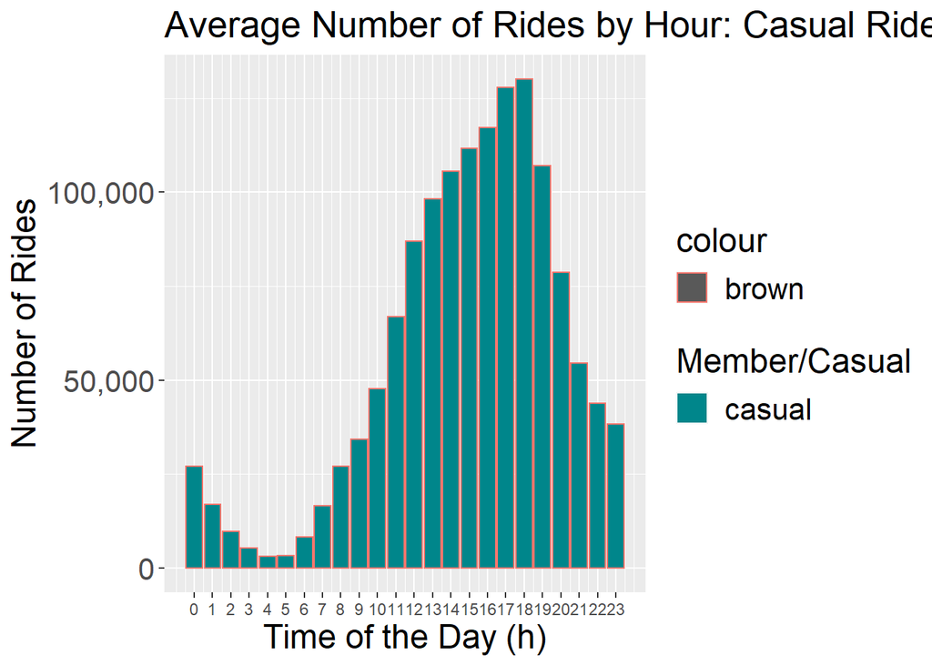

```r
options(repr.plot.width = 12, repr.plot.height = 8)

Divvy_2020_data %>%
  filter(member_casual == 'casual') %>%
  group_by(hour_of_day = hour(round_date(started_at, 'hour'))) %>%
  group_by(hour_of_day, member_casual) %>%
  summarize(number_of_rides = n(), .groups = 'drop') %>%
  arrange(-number_of_rides) %>%
  ggplot(aes(x = hour_of_day, y = number_of_rides, fill = member_casual , color="brown")) +
  scale_fill_manual(values=c("casual"="turquoise4"))+
  geom_bar(position = 'dodge', stat = 'identity') + scale_y_continuous(labels = scales::comma) +
  scale_x_continuous(breaks = c(0,1,2,3,4,5,6,7,8,9,10,11,12,13,14,15,16,17,18,19,20,21,22,23)) +
  labs(x = "Time of the Day (h)", y = "Number of Rides",
       fill = "Member/Casual",
       title = "Average Number of Rides by Hour: Casual Riders") + custom_theme
```

### Top 10 start stations (casual riders)

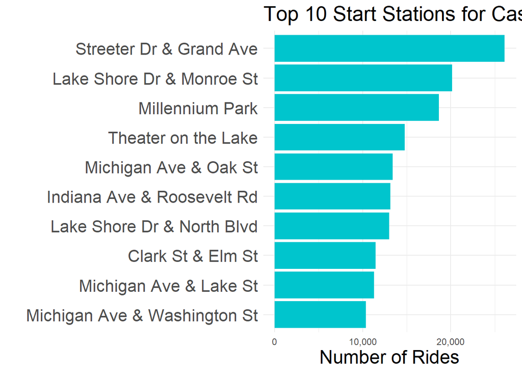

```r
options(repr.plot.width = 10, repr.plot.height = 6)

Divvy_2020_data %>%
  group_by(start_station_name, member_casual) %>%
  summarize(number_of_rides = n(), .groups = 'drop') %>%
  filter(start_station_name != "", member_casual != "member") %>%
  arrange(-number_of_rides) %>%
  head(n=10) %>%
  ggplot(aes(x = reorder(start_station_name, number_of_rides), y = number_of_rides)) +
  geom_col(position = 'dodge', fill = "turquoise3") +
  scale_y_continuous(labels = scales::comma) +
  labs(title = 'Top 10 Start Stations for Casual Riders', x = '', y = "Number of Rides") +
  coord_flip() +
  theme_minimal() +
  custom_theme
```

### Usage of different bikes by rider type

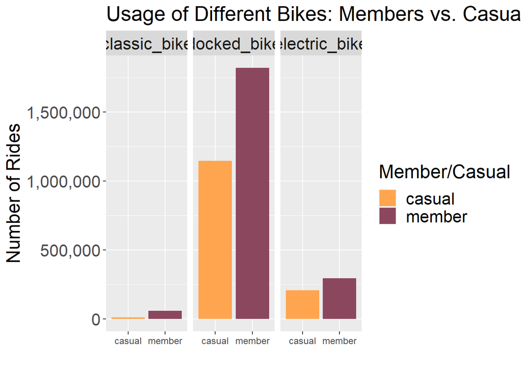

```r
options(repr.plot.width = 12, repr.plot.height = 8)

Divvy_2020_data %>%
  group_by(rideable_type, member_casual) %>%
  summarize(number_of_rides = n(), .groups = 'drop') %>%
  drop_na() %>%
  ggplot(aes(x = member_casual, y = number_of_rides, fill = member_casual)) +
  geom_col(position = "dodge") +
  scale_fill_manual(values=c("casual"="tan1","member"="palevioletred4" )) +
  scale_y_continuous(labels = scales::comma) +
  facet_wrap(~rideable_type) +
  labs(fill = "Member/Casual", x = "", y = "Number of Rides",
       title = "Usage of Different Bikes: Members vs. Casual Riders") + custom_theme
```

### usage of different bikes by rider type (separated)

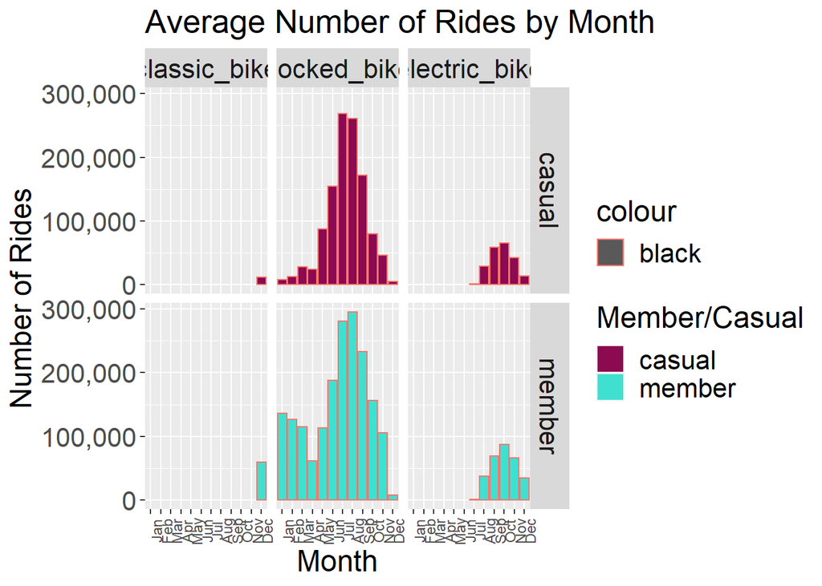

```r
options(repr.plot.width = 14, repr.plot.height = 10)

Divvy_2020_data %>%
  mutate(month_name=month(started_at,label=TRUE))%>%
  group_by(month_name, member_casual, rideable_type) %>%
  summarize(number_of_rides = n(), .groups = 'drop') %>%
  drop_na() %>%
  ggplot(aes(x = month_name, y = number_of_rides, fill = member_casual,color="black")) +
  geom_col(position = "dodge") +
  scale_fill_manual(values=c("casual"="deeppink4","member"="turquoise"))+
  scale_y_continuous(labels = scales::comma) +
  facet_grid(member_casual~rideable_type) +
  labs(x = "Month", y = "Number of Rides", fill = "Member/Casual",
       title = "Average Number of Rides by Month") +
  theme(axis.text.x = element_text(angle = 90)) + custom_theme
```

### Number of rides between members and casual riders by day of week across the year

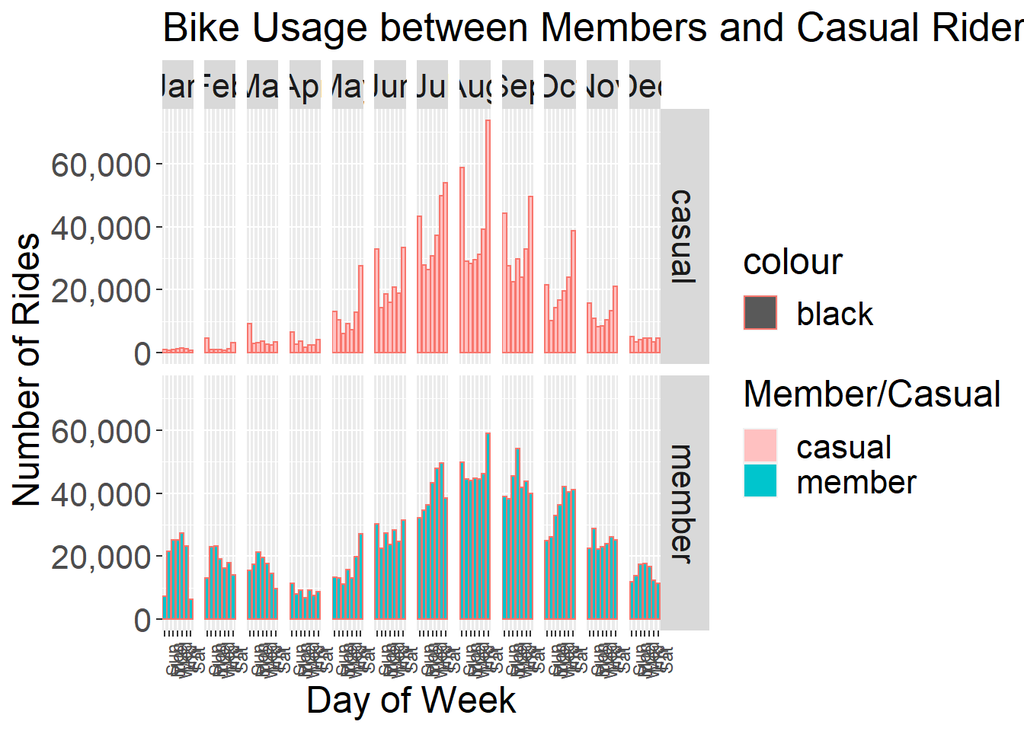

```r
options(repr.plot.width = 26, repr.plot.height = 10)

Divvy_2020_data %>%
  mutate(month_name=month(started_at,label=TRUE),weekday=wday(started_at,label=TRUE))%>%
  group_by(month_name, weekday, member_casual) %>%
  summarize(number_of_rides = n(), .groups = 'drop') %>%
  drop_na() %>%
  ggplot(aes(x = weekday, y = number_of_rides, fill = member_casual,color="black")) +
  geom_col(position = "dodge") +
  scale_fill_manual(values = c("casual"="rosybrown1","member"="turquoise3"))+
  scale_y_continuous(labels = scales::comma) +
  facet_grid(member_casual~month_name) +
  labs(x = "Day of Week", y = "Number of Rides", fill = "Member/Casual",
       title = "Bike Usage between Members and Casual Riders by Day of Week across the Year", fill = 'Member/Casual') +
  theme(axis.text.x = element_text(angle = 90)) +
  custom_theme
```